# Coursework Report

*N* removed NAs: 7

*N* removed <18: 20

**Correct typo age:** 18

*N* total clean: 141

| Group | *N* | *M*<sub>age</sub> | % green |
| --- | --- | --- | --- |
| Control | 70 | 20.73 | 39.05 |
| Experim | 71 | 20.75 | 52.11 |

| Gender | *N* | *M*<sub>age</sub> | % green |
| --- | --- | --- | --- |
| Female | 73 | 20.78 | 45.66 |
| Male | 41 | 21.17 | 44.72 |
| Other | 27 | 19.96 | 46.91 |

**Main analysis results**

**car:**  
χ<sup>2</sup>(1) = 1.65, *p* = .198

**cleaner:**  
χ<sup>2</sup>(1) = 7.73, *p* = .005

**dishwasher:**  
χ<sup>2</sup>(1) = 0.01, *p* = .924

[interactive chart not shown]

[figure not shown]

[interactive chart not shown]

# Coursework Report

Analysing Data, Spring 2020

# Methods

## Participants

Table 1 shows the number and age of participants in the two experimental conditions broken down by gender.

Table 1 *Summary of Participant Demographics by Experimental Condition*

[output not shown]

## Design

This study aimed to examine if buying “green” products is related to status motives.

The two variables are the story-condition and the product choice. Story-condition is operationalised as reading high-status or status-neutral story. Product choice is operationalised as green or more luxurious non-green product. The three products were: car, cleaner and dishwasher.

In both status and control conditions, the participants were randomly allocated and were asked to read a passage then answer questions about the preference for 3 products. Product choice is created with two levels: “luxury” or “green”

In the status condition, the aim was to elicit status motives. This was done by reading a passage, which has been previously successfully used, to elicit status motives. In the control condition, they also read a similar length passage which was designed to elicit similar levels of affect as the status story.

The higher the choice frequency for a product, the greater the preference. Green products should be chosen more frequently in the high-status condition as it elicits status motives than people in the control condition. To test this the statistical analysis chi-squared will be used to analyse the association between the status condition and the preference for each of the products.

# Results

Overall, an increase in the preference for the greener products were found when status motives were elicited on all of the products compared to those in the control group.

The most significant change was seen in cleaners where the number of people who chose the green cleaner in the control group (26) increased to 44 in the experiment group as seen in Figure 3.

Likewise, an increase was also observed for green cars were preference for it increased from 26 in the control group to 35 in the experimental group as seen in Figure 1.

Preference for green dishwashers on the other hand did not show a large increase in preference from the control (30) to the experimental group (32). Instead equal preference was seen (Figure 2).

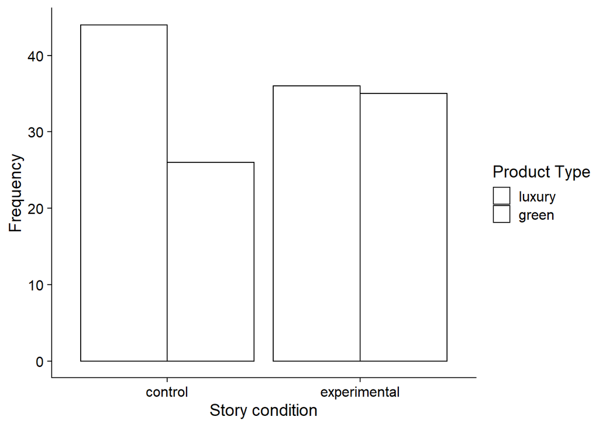

*Figure 1*. The frequency of the different type of car selected by story condition.

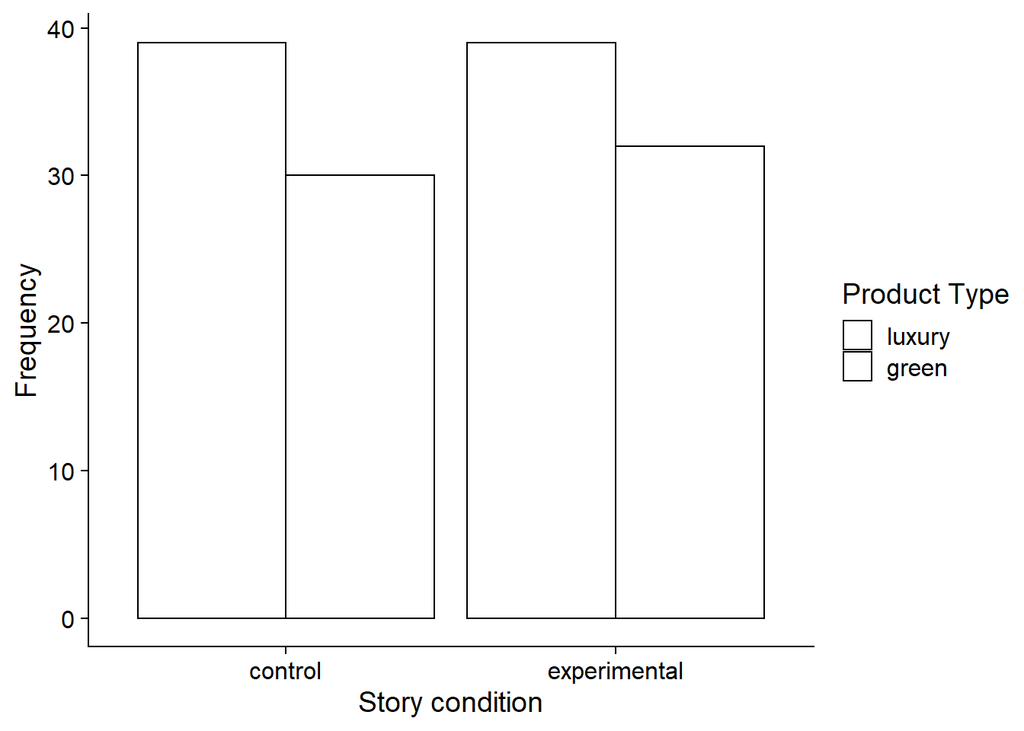

*Figure 2*. The frequency of the different type of dishwasher selected by story condition.

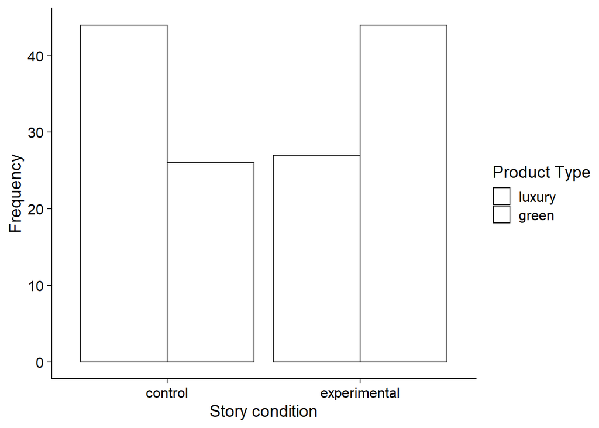

*Figure 3*. The frequency of the different type of cleaner selected by story condition.

# Discussion

Overall, the findings of this study do support the association between status motives and green product choices as a general pattern can be seem where status motives are likely to increase the preference of greener products. This posits eliciting status motives as a technique to increase the consumer’s greener product choices therefore engaging in more pro-environmental behaviours.

A limitation of the study is how the products, green or luxurious, were the same price. Often greener products are more costly (Noppers, Keizer, Bolderdijk & Steg, 2014) and this could be a big influencer in whether participants are affected in their product reference by status motives.

Based on our own analysis and other studies looking into the similar area (Noppers et al, 2014; Van der Wal, Horen & Grinstein, 2016), a general overall effect has been found where by status motives influence product preference making this effect worth investigating further with some of the following recommendations.

Noppers et al (2014) found when they interviewed participants on why they chose to purchase a green car, the participants said it was to help the environment but the evaluation of symbolic attribution showed it was more to do with symbolic attribution which they were not aware of themselves.

This can help explain the difference found between our study and Griskevic et al (2010) suggesting there is more to investigate in order to explain the diferences in the product choices. Specifically, for our study, the increase in greener car preference found in both this study and Griskevic et al (2010) study’s may be justified by conscpicuousness.

Cars are far more likely to be seen in public compared to a cleaner or a dishwasher which may explain the increase in the preference for a green car in both our study and Griskevic et al (2010) study as it is much more conspicuous.

Aagerup & Nilsson (2016) found when participants were given the option to pick an organic coffee or normal coffee, their choice was influenced by the conspicuousness of their choice. Participants who anticipated a conspicuous consumption situation (clear cup) chose environmentally friendly products to a greater extent than participants who anticipated an inconspicuous consumption situation (opaque cup).

Consequently, it may be of benefit for studies in the future to conduct the experiment with the addition of a symbolic attribution evaluation or manipulating variables regarding how conspicuous or inconspicuous the products are as well as experimenting with the prices.

# References

Aagerup, U., & Nilsson, J. (2016). Green consumer behaviour: being good or seeming good? *Journal of Product & Braind Management, 25*(3), 274-284.

Griskevic, V., Van den Bergh, B., & Tybur, J.M. (2010). Going Green to Be Seen: Status, Reputation, and Conspicuous Conservation. *Journal of Personality and Social Psychology, 98*(3), 392-404.

Noppers, E.H., Keizer, K., Bolderdijk, J.W., & Steg, L. (2014). The adoption of sustainable innovations: Driven by symbolic and environmental motives.*Global Environmental Change, 25*(), 52-62.

Van der Wal, A.J., Horen, F.V., & Grinstein, A. (2016). The paradox of ‘green to be seen’: Green high-status shoppers excessively use (branded) shopping bags. *International Journal of Research in Marketing, 33*(1), 216-219.